# Exercise_11.3

## Exercise 11.3 (Impute the missing values with STL)

- Use the smoothed time series with gaps from the first exercise as input.
- The STL needs data that is complete, i.e., without missing values. Therefore, first impute the missing values using a simple method of your choice (e.g., linear interpolation).
- Then, apply the STL decomposition to the imputed time series.
- Visualize the decomposed components (trend, seasonal, residual) using the provided seasonal_decompose_seaborn function.
- The seasonal part of the decomposition can now be used to deseasonalize the smoothed time series with gaps.
- Now that we have a deseasonalized time series with missing values, we can again impute the missing values using a simple method of your choice.
- Finally, reseasonalize the imputed deseasonalized time series by adding back the seasonal component obtained from the STL decomposition.
- Visualize the final imputed time series using the provided plot_production_data function.
- Discuss the results.

# 1 Load the smoothed time series with gaps from 11.1

```python
import pandas as pd
import matplotlib.pyplot as plt
import seaborn as sns
from statsmodels.tsa.seasonal import STL

# Lädt den Produktionsdatensatz aus dem Vorlesungsskript.
url = "https://noxthot.github.io/ws26_industrial_datascience_manuscript/data/assets/act1/selfstudysessions/sss1_production_data.csv"

# Liest die CSV-Datei ein und konvertiert die Spalte "Date" in das Datetime-Format.
df = pd.read_csv(url, parse_dates=["Date"])
df = df.set_index("Date")

# Glättet die Produktionsdaten mit einem gleitenden Median. Analog zur Aufgabe 11.1
df["pieces_median"] = (
    df["pieces_gaps"]
    .rolling(window=7, center=True, min_periods=2)  # Window 7, Reduziert kurzfristige Schwankungen, behält aber langfristigen Trend und saisonale Schwankungen bei.
    .median()
)

# Erhält die ursprünglichen Datenlücken in beiden Ergebnissen.
df.loc[df["pieces_gaps"].isna(),  "pieces_median"] = float("nan")
```

# 2 Imputation using linear interpolation

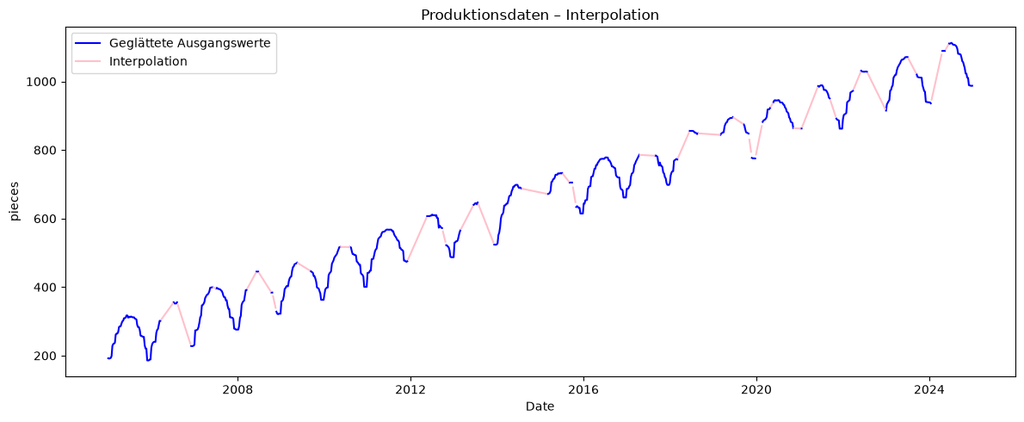

```python
# Linear Interpolation: Füllt die Lücken in den geglätteten Produktionsdaten mit linear interpolierten Werten auf.
df.loc[:, "pieces_lin_interpolated"] = df["pieces_median"].interpolate()     # .interpolate() füllt die NaN-Werte mit linear interpolierten Werten auf.


# Ausgabe der Plots
fig, ax = plt.subplots(figsize=(12, 5))

# Geglättete Ausgangswerte mit unterbrochenen Datenlücken.
ax.plot(
    df.index,
    df["pieces_median"],
    color="blue",
    label="Geglättete Ausgangswerte"
)

# Zeigt nur die durch Interpolation ergänzten Werte.
filled_values = df["pieces_lin_interpolated"].where(
    df["pieces_median"].isna()
)

ax.plot(
    df.index,
    filled_values,
    color="pink",
    label="Interpolation"
)

ax.set_title("Produktionsdaten – Interpolation")
ax.set_xlabel("Date")
ax.set_ylabel("pieces")
ax.legend()

plt.tight_layout()
plt.show()
```

# Apply the STL decomposition (Seasonal and Trend decomposition using Loess)

```python
# Zerlegt die aufgefüllte Zeitreihe (yt) in Trend (Tt), Saison (St) und Rest (Rt). yt = Tt + St + Rt
decomp_stl = STL(
    df["pieces_lin_interpolated"],      # Die Zeitreihe, die zerlegt werden soll.
    period=52,                          # Periodenlänge von 52 Wochen für die saisonale Komponente (1 Jahr).
    robust=True                         # Robustheit gegen Ausreißer in der Zeitreihe
).fit()
```

# Visualize the decomposed components using seasonal_decompose_seaborn

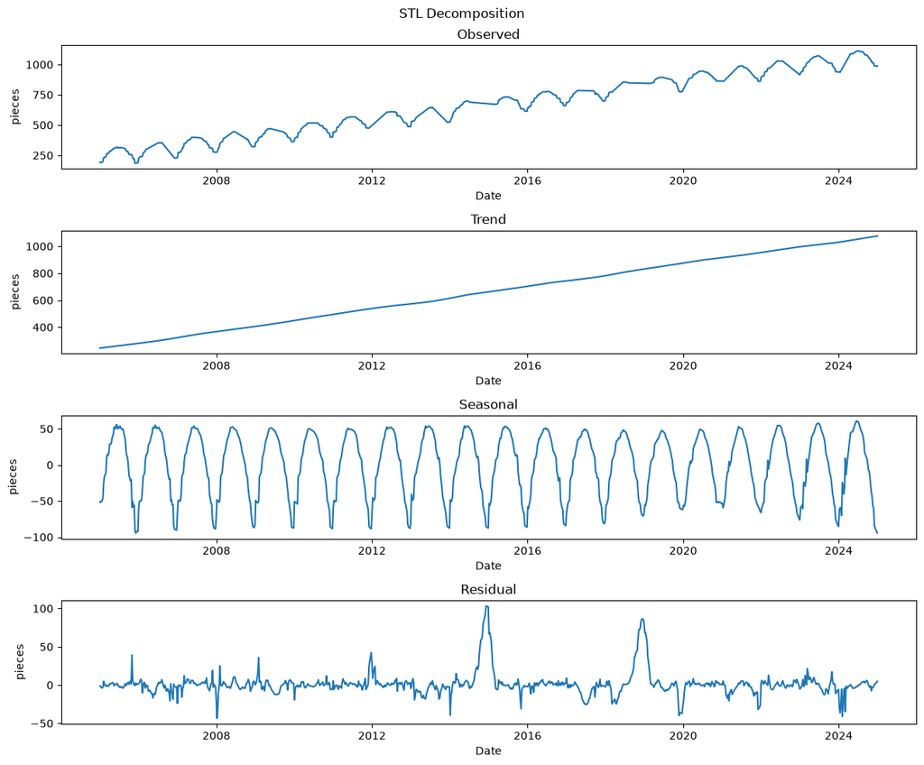

```python
def seasonal_decompose_seaborn(decomposed_ts, title):
    """
    Plots a decomposed time series using seaborn.
    Parameters:
      decomposed_ts (DecomposeResult): Result of STL or seasonal_decompose.
      title (str): Title for the plot.
    """
    fig, axes = plt.subplots(4, 1, figsize=(12, 10))

    sns.lineplot(x=decomposed_ts.observed.index, y=decomposed_ts.observed.values, ax=axes[0])
    axes[0].set_title("Observed")
    axes[0].set_ylabel("pieces")

    sns.lineplot(x=decomposed_ts.trend.index, y=decomposed_ts.trend.values, ax=axes[1])
    axes[1].set_title("Trend")
    axes[1].set_ylabel("pieces")

    sns.lineplot(x=decomposed_ts.seasonal.index, y=decomposed_ts.seasonal.values, ax=axes[2])
    axes[2].set_title("Seasonal")
    axes[2].set_ylabel("pieces")

    sns.lineplot(x=decomposed_ts.resid.index, y=decomposed_ts.resid.values, ax=axes[3])
    axes[3].set_title("Residual")
    axes[3].set_ylabel("pieces")

    plt.suptitle(title)
    plt.tight_layout()
    plt.show()


# Aufruf der Funktion zur Visualisierung der STL-Zerlegung
seasonal_decompose_seaborn(decomp_stl, title="STL Decomposition")
```

# Deseasonalize the smoothed time series with gaps

```python
# Entfernt den saisonalen Anteil aus der geglätteten Reihe mit Lücken.
df["pieces_deseasonalized"] = (df["pieces_median"] - decomp_stl.seasonal)
```

# Impute the missing values in the deseasonalized using linear interpolation

```python
# Füllt die Lücken in der saisonbereinigten Reihe linear auf.
df["pieces_deseasonalized_imputed"] = (
    df["pieces_deseasonalized"].interpolate(method="linear")
)
```

# Reseasonalize the imputed deseasonalized time series by adding back the seasonal component obtained from the STL decomposition

```python
# Fügt den saisonalen Anteil wieder hinzu.
df["pieces_stl_imputed"] = (
    df["pieces_deseasonalized_imputed"] + decomp_stl.seasonal
)
```

# Visualize the final imputed time series using plot_production_data function

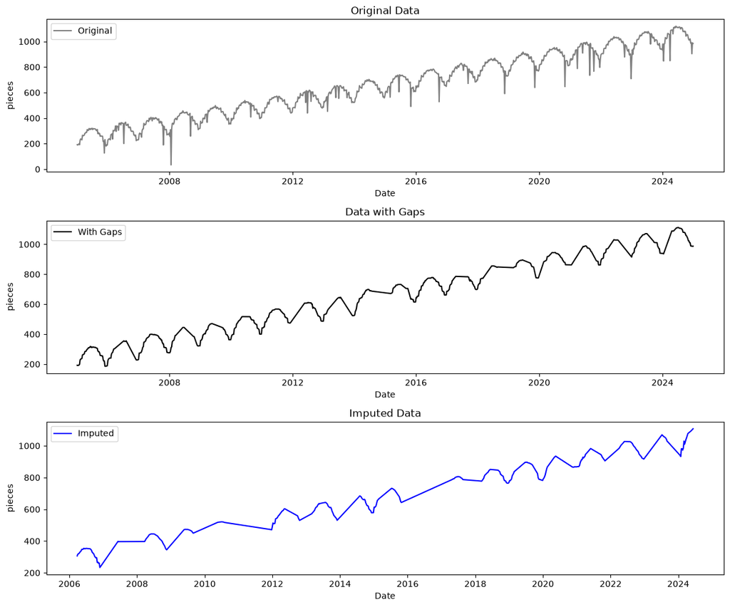

```python
# Funktion zur Visualisierung der Produktionsdaten
def plot_production_data(
    df,
    orig_data_column,
    gap_column,
    imp_column=None,
):
    """
    Plots production data with and without gaps using seaborn.
    Parameters:
      df (DataFrame): DataFrame containing the production data.
      orig_data_column (str): Column name for the original data.
      gap_column (str): Column name for the data with gaps.
      imp_column (str): Column name for the imputed data.
    """
    fig, axes = plt.subplots(3 if imp_column else 2, 1, figsize=(12, 10))

    # Original data
    sns.lineplot(x=df.index, y=df[orig_data_column], ax=axes[0], color="grey", label="Original")
    axes[0].set_title("Original Data")
    axes[0].set_ylabel("pieces")

    # With gaps
    sns.lineplot(x=df.index, y=df[gap_column], ax=axes[1], color="black", label="With Gaps")
    axes[1].set_title("Data with Gaps")
    axes[1].set_ylabel("pieces")

    if imp_column is not None:
        dff = df[[gap_column, imp_column]].copy()
        dff.loc[~df[gap_column].isna(), imp_column] = None
        sns.lineplot(x=dff.index, y=dff[imp_column], ax=axes[2], color="blue", label="Imputed")
        axes[2].set_title("Imputed Data")
        axes[2].set_ylabel("pieces")

    plt.tight_layout()
    plt.show()


# Aufruf der Funktion zur Visualisierung der Produktionsdaten
plot_production_data(
    df,
    orig_data_column="pieces",
    gap_column="pieces_median",
    imp_column="pieces_stl_imputed"
)
```

# 4 Discussion of the Results

Die STL-Zerlegung zeigt einen langfristig steigenden Trend und eine deutlich erkennbare jährliche Saisonalität. Der Rest liegt überwiegend nahe null. Größere Abweichungen treten unter anderem um 2015 und 2019 auf. In diesen Bereichen bildet die vorläufige lineare Interpolation die saisonalen Tiefpunkte nicht ab.

Nach dem Entfernen der saisonalen Komponente werden die Lücken in der saisonbereinigten Reihe linear aufgefüllt. Durch das anschließende Addieren der Saison erhalten auch die ergänzten Bereiche wieder die typischen jährlichen Schwankungen. Die vorhandenen Werte der geglätteten Ausgangsreihe bleiben erhalten.

Im Vergleich zur direkten linearen Interpolation werden saisonale Verläufe innerhalb längerer Lücken besser nachgebildet. Die Rekonstruktion ist jedoch nicht überall exakt. Die saisonale Komponente wird aus einer bereits vorläufig aufgefüllten Reihe geschätzt und kann dadurch beeinflusst werden. Für die vorliegenden Daten ist das Vorgehen mit STL insgesamt besser geeignet, da es neben dem langfristigen Verlauf auch die jährlichen Schwankungen berücksichtigt.

ipynb exportiert als html mit:

uv run jupyter nbconvert --to html "Tasks/11 Self study - Session 2/Exercise_11.3.ipynb"